# Sprint_4_Development

Artificial Intelligence for Business Decisions and Transformation

CSCN8030 - Spring 2024 - Section 2

Professor: Glaucia Melo dos Santos, PhD

Group 4 - Members:

Krishna Kumar, Hemasree  
Shijin, Jency  
Fernandez, Arcadio

## Sprint 4 Development:

# Project: Loblaws Digital - predict customer attrition and determine strategies

# 1. Introduction: A brief introduction to the problem, libraries and obtaining the data.

### 1.1. A brief introduction to the problem

Loblaws Digital faces the challenge of identifying customers who are likely to churn and developing strategies to retain them. Predicting customer attrition and understanding the factors contributing to it can help Loblaws Digital take proactive measures to enhance customer loyalty and reduce churn rates.

Goal :

The primary goal of this project is to build a predictive model that accurately identifies customers at risk of leaving the company based on various customer-related variables. By leveraging the insights gained from the model, Loblaws Digital can implement targeted retention strategies to keep customers loyal. Additionally, a thorough exploratory analysis of the provided customer data will help uncover patterns and trends, offering valuable insights into customer behavior and informing future decision-making.

Dataset :

The dataset provided contains various attributes related to customers of Loblaws Digital. Each row represents a unique customer, and the columns represent different attributes or features associated with the customers

1. CustomerID: A unique identifier for each customer.
2. Churn: Indicates whether the customer has churned (1) or not (0).
3. Tenure: The duration (in months) that the customer has been with the organization.
4. PreferredLoginDevice: The device (e.g., mobile phone, computer) that the customer primarily uses to log into their account.
5. CityTier: The tier of the city where the customer resides, indicating the city's economic and demographic classification.
6. WarehouseToHome: The distance (in kilometers) between the warehouse and the customer's home.
7. PreferredPaymentMode: The payment method (e.g., credit card, debit card, UPI) that the customer prefers to use.
8. Gender: The gender of the customer (e.g., male, female).
9. HourSpendOnApp: The number of hours the customer spends on the mobile application or website.
10. NumberOfDeviceRegistered: The total number of devices registered under the customer's account.
11. PreferedOrderCat: The category of products that the customer preferred to order in the last month.
12. SatisfactionScore: The customer's satisfaction score with the service, typically rated on a scale from 1 to 5.
13. MaritalStatus: The marital status of the customer (e.g., single, married, divorced).
14. NumberOfAddress: The total number of addresses added to the customer's account.
15. Complain: Indicates if the customer has raised any complaints in the last month (1 for yes, 0 for no).
16. OrderAmountHikeFromlastYear: The percentage increase in the order amount compared to the previous year.
17. CouponUsed: The total number of coupons used by the customer in the last month.
18. OrderCount: The total number of orders placed by the customer in the last month.
19. DaySinceLastOrder: The number of days since the customer last placed an order.
20. CashbackAmount: The average cashback amount received by the customer in the last month

### 1.2. Importing all the essential libraries and sub modules

```python
# Import Libraries
import numpy as np
import pandas as pd
import os
import seaborn as sns
from matplotlib import pyplot as plt
```

### 1.3. Obtaining the Data

```python
import pandas as pd

# Load the data from excel files to dataframe
data_path = "loblaws.xlsx"
customer_df = pd.read_excel(data_path, sheet_name='E Comm')
```

```python
display(customer_df)
```

|  | CustomerID | Churn | Tenure | PreferredLoginDevice | CityTier | WarehouseToHome | PreferredPaymentMode | Gender | HourSpendOnApp | NumberOfDeviceRegistered | PreferedOrderCat | SatisfactionScore | MaritalStatus | NumberOfAddress | Complain | OrderAmountHikeFromlastYear | CouponUsed | OrderCount | DaySinceLastOrder | CashbackAmount |
| --- | --- | --- | --- | --- | --- | --- | --- | --- | --- | --- | --- | --- | --- | --- | --- | --- | --- | --- | --- | --- |
| 0 | 50001 | 1 | 4.0 | Mobile Phone | 3 | 6.0 | Debit Card | Female | 3.0 | 3 | Laptop & Accessory | 2 | Single | 9 | 1 | 11.0 | 1.0 | 1.0 | 5.0 | 159.93 |
| 1 | 50002 | 1 | NaN | Phone | 1 | 8.0 | UPI | Male | 3.0 | 4 | Mobile | 3 | Single | 7 | 1 | 15.0 | 0.0 | 1.0 | 0.0 | 120.90 |
| 2 | 50003 | 1 | NaN | Phone | 1 | 30.0 | Debit Card | Male | 2.0 | 4 | Mobile | 3 | Single | 6 | 1 | 14.0 | 0.0 | 1.0 | 3.0 | 120.28 |
| 3 | 50004 | 1 | 0.0 | Phone | 3 | 15.0 | Debit Card | Male | 2.0 | 4 | Laptop & Accessory | 5 | Single | 8 | 0 | 23.0 | 0.0 | 1.0 | 3.0 | 134.07 |
| 4 | 50005 | 1 | 0.0 | Phone | 1 | 12.0 | CC | Male | NaN | 3 | Mobile | 5 | Single | 3 | 0 | 11.0 | 1.0 | 1.0 | 3.0 | 129.60 |
| ... | ... | ... | ... | ... | ... | ... | ... | ... | ... | ... | ... | ... | ... | ... | ... | ... | ... | ... | ... | ... |
| 5625 | 55626 | 0 | 10.0 | Computer | 1 | 30.0 | Credit Card | Male | 3.0 | 2 | Laptop & Accessory | 1 | Married | 6 | 0 | 18.0 | 1.0 | 2.0 | 4.0 | 150.71 |
| 5626 | 55627 | 0 | 13.0 | Mobile Phone | 1 | 13.0 | Credit Card | Male | 3.0 | 5 | Fashion | 5 | Married | 6 | 0 | 16.0 | 1.0 | 2.0 | NaN | 224.91 |
| 5627 | 55628 | 0 | 1.0 | Mobile Phone | 1 | 11.0 | Debit Card | Male | 3.0 | 2 | Laptop & Accessory | 4 | Married | 3 | 1 | 21.0 | 1.0 | 2.0 | 4.0 | 186.42 |
| 5628 | 55629 | 0 | 23.0 | Computer | 3 | 9.0 | Credit Card | Male | 4.0 | 5 | Laptop & Accessory | 4 | Married | 4 | 0 | 15.0 | 2.0 | 2.0 | 9.0 | 178.90 |
| 5629 | 55630 | 0 | 8.0 | Mobile Phone | 1 | 15.0 | Credit Card | Male | 3.0 | 2 | Laptop & Accessory | 3 | Married | 4 | 0 | 13.0 | 2.0 | 2.0 | 3.0 | 169.04 |

5630 rows × 20 columns

# 2. Exploratory data analysis - EDA

## 2.1. Basic data analysis

```python
# Checking the dataset shape
print(customer_df.shape)
```

```
(5630, 20)
```

The dataframe has 5630 entries (rows) and 20 columns.

```python
# Viewing the first few rows of the dataset
customer_df.head()
```

|  | CustomerID | Churn | Tenure | PreferredLoginDevice | CityTier | WarehouseToHome | PreferredPaymentMode | Gender | HourSpendOnApp | NumberOfDeviceRegistered | PreferedOrderCat | SatisfactionScore | MaritalStatus | NumberOfAddress | Complain | OrderAmountHikeFromlastYear | CouponUsed | OrderCount | DaySinceLastOrder | CashbackAmount |
| --- | --- | --- | --- | --- | --- | --- | --- | --- | --- | --- | --- | --- | --- | --- | --- | --- | --- | --- | --- | --- |
| 0 | 50001 | 1 | 4.0 | Mobile Phone | 3 | 6.0 | Debit Card | Female | 3.0 | 3 | Laptop & Accessory | 2 | Single | 9 | 1 | 11.0 | 1.0 | 1.0 | 5.0 | 159.93 |
| 1 | 50002 | 1 | NaN | Phone | 1 | 8.0 | UPI | Male | 3.0 | 4 | Mobile | 3 | Single | 7 | 1 | 15.0 | 0.0 | 1.0 | 0.0 | 120.90 |
| 2 | 50003 | 1 | NaN | Phone | 1 | 30.0 | Debit Card | Male | 2.0 | 4 | Mobile | 3 | Single | 6 | 1 | 14.0 | 0.0 | 1.0 | 3.0 | 120.28 |
| 3 | 50004 | 1 | 0.0 | Phone | 3 | 15.0 | Debit Card | Male | 2.0 | 4 | Laptop & Accessory | 5 | Single | 8 | 0 | 23.0 | 0.0 | 1.0 | 3.0 | 134.07 |
| 4 | 50005 | 1 | 0.0 | Phone | 1 | 12.0 | CC | Male | NaN | 3 | Mobile | 5 | Single | 3 | 0 | 11.0 | 1.0 | 1.0 | 3.0 | 129.60 |

```python
customer_df.info()
```

```
<class 'pandas.core.frame.DataFrame'>
RangeIndex: 5630 entries, 0 to 5629
Data columns (total 20 columns):
 #   Column                       Non-Null Count  Dtype
---  ------                       --------------  -----
 0   CustomerID                   5630 non-null   int64
 1   Churn                        5630 non-null   int64
 2   Tenure                       5366 non-null   float64
 3   PreferredLoginDevice         5630 non-null   object
 4   CityTier                     5630 non-null   int64
 5   WarehouseToHome              5379 non-null   float64
 6   PreferredPaymentMode         5630 non-null   object
 7   Gender                       5630 non-null   object
 8   HourSpendOnApp               5375 non-null   float64
 9   NumberOfDeviceRegistered     5630 non-null   int64
 10  PreferedOrderCat             5630 non-null   object
 11  SatisfactionScore            5630 non-null   int64
 12  MaritalStatus                5630 non-null   object
 13  NumberOfAddress              5630 non-null   int64
 14  Complain                     5630 non-null   int64
 15  OrderAmountHikeFromlastYear  5365 non-null   float64
 16  CouponUsed                   5374 non-null   float64
 17  OrderCount                   5372 non-null   float64
 18  DaySinceLastOrder            5323 non-null   float64
 19  CashbackAmount               5630 non-null   float64
dtypes: float64(8), int64(7), object(5)
memory usage: 879.8+ KB
```

```python
customer_df.dtypes
```

```
CustomerID                       int64
Churn                            int64
Tenure                         float64
PreferredLoginDevice            object
CityTier                         int64
WarehouseToHome                float64
PreferredPaymentMode            object
Gender                          object
HourSpendOnApp                 float64
NumberOfDeviceRegistered         int64
PreferedOrderCat                object
SatisfactionScore                int64
MaritalStatus                   object
NumberOfAddress                  int64
Complain                         int64
OrderAmountHikeFromlastYear    float64
CouponUsed                     float64
OrderCount                     float64
DaySinceLastOrder              float64
CashbackAmount                 float64
dtype: object
```

```python
customer_df.nunique()
```

```
CustomerID                     5630
Churn                             2
Tenure                           36
PreferredLoginDevice              3
CityTier                          3
WarehouseToHome                  34
PreferredPaymentMode              7
Gender                            2
HourSpendOnApp                    6
NumberOfDeviceRegistered          6
PreferedOrderCat                  6
SatisfactionScore                 5
MaritalStatus                     3
NumberOfAddress                  15
Complain                          2
OrderAmountHikeFromlastYear      16
CouponUsed                       17
OrderCount                       16
DaySinceLastOrder                22
CashbackAmount                 2586
dtype: int64
```

## 2.2. Statistical analysis

```python
customer_df.describe(include='all')
```

|  | CustomerID | Churn | Tenure | PreferredLoginDevice | CityTier | WarehouseToHome | PreferredPaymentMode | Gender | HourSpendOnApp | NumberOfDeviceRegistered | PreferedOrderCat | SatisfactionScore | MaritalStatus | NumberOfAddress | Complain | OrderAmountHikeFromlastYear | CouponUsed | OrderCount | DaySinceLastOrder | CashbackAmount |
| --- | --- | --- | --- | --- | --- | --- | --- | --- | --- | --- | --- | --- | --- | --- | --- | --- | --- | --- | --- | --- |
| count | 5630.000000 | 5630.000000 | 5366.000000 | 5630 | 5630.000000 | 5379.000000 | 5630 | 5630 | 5375.000000 | 5630.000000 | 5630 | 5630.000000 | 5630 | 5630.000000 | 5630.000000 | 5365.000000 | 5374.000000 | 5372.000000 | 5323.000000 | 5630.000000 |
| unique | NaN | NaN | NaN | 3 | NaN | NaN | 7 | 2 | NaN | NaN | 6 | NaN | 3 | NaN | NaN | NaN | NaN | NaN | NaN | NaN |
| top | NaN | NaN | NaN | Mobile Phone | NaN | NaN | Debit Card | Male | NaN | NaN | Laptop & Accessory | NaN | Married | NaN | NaN | NaN | NaN | NaN | NaN | NaN |
| freq | NaN | NaN | NaN | 2765 | NaN | NaN | 2314 | 3384 | NaN | NaN | 2050 | NaN | 2986 | NaN | NaN | NaN | NaN | NaN | NaN | NaN |
| mean | 52815.500000 | 0.168384 | 10.189899 | NaN | 1.654707 | 15.639896 | NaN | NaN | 2.931535 | 3.688988 | NaN | 3.066785 | NaN | 4.214032 | 0.284902 | 15.707922 | 1.751023 | 3.008004 | 4.543491 | 177.223030 |
| std | 1625.385339 | 0.374240 | 8.557241 | NaN | 0.915389 | 8.531475 | NaN | NaN | 0.721926 | 1.023999 | NaN | 1.380194 | NaN | 2.583586 | 0.451408 | 3.675485 | 1.894621 | 2.939680 | 3.654433 | 49.207036 |
| min | 50001.000000 | 0.000000 | 0.000000 | NaN | 1.000000 | 5.000000 | NaN | NaN | 0.000000 | 1.000000 | NaN | 1.000000 | NaN | 1.000000 | 0.000000 | 11.000000 | 0.000000 | 1.000000 | 0.000000 | 0.000000 |
| 25% | 51408.250000 | 0.000000 | 2.000000 | NaN | 1.000000 | 9.000000 | NaN | NaN | 2.000000 | 3.000000 | NaN | 2.000000 | NaN | 2.000000 | 0.000000 | 13.000000 | 1.000000 | 1.000000 | 2.000000 | 145.770000 |
| 50% | 52815.500000 | 0.000000 | 9.000000 | NaN | 1.000000 | 14.000000 | NaN | NaN | 3.000000 | 4.000000 | NaN | 3.000000 | NaN | 3.000000 | 0.000000 | 15.000000 | 1.000000 | 2.000000 | 3.000000 | 163.280000 |
| 75% | 54222.750000 | 0.000000 | 16.000000 | NaN | 3.000000 | 20.000000 | NaN | NaN | 3.000000 | 4.000000 | NaN | 4.000000 | NaN | 6.000000 | 1.000000 | 18.000000 | 2.000000 | 3.000000 | 7.000000 | 196.392500 |
| max | 55630.000000 | 1.000000 | 61.000000 | NaN | 3.000000 | 127.000000 | NaN | NaN | 5.000000 | 6.000000 | NaN | 5.000000 | NaN | 22.000000 | 1.000000 | 26.000000 | 16.000000 | 16.000000 | 46.000000 | 324.990000 |

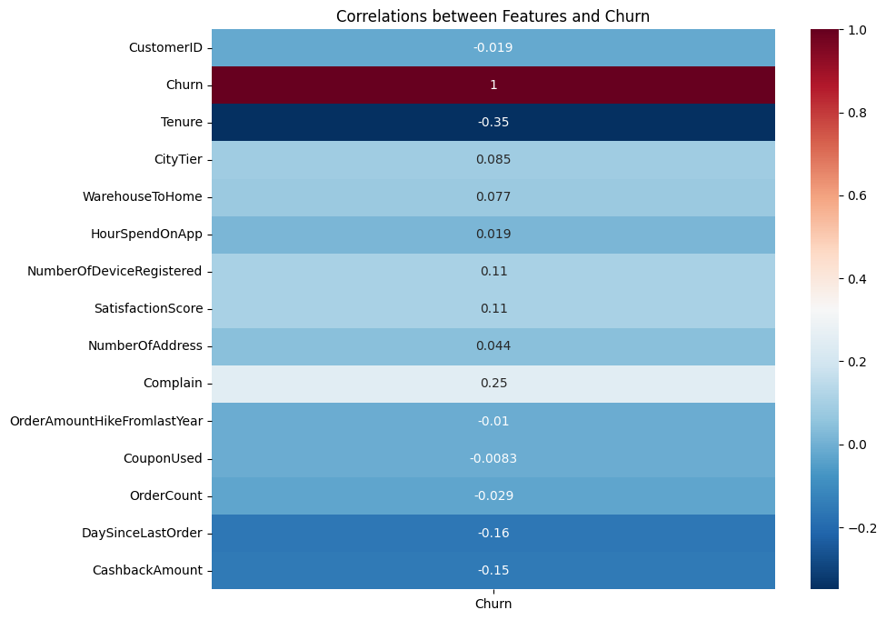

```python
corr_matrix = customer_df.corr(numeric_only=True)

plt.figure(figsize=(10, 8))
sns.heatmap(corr_matrix[['Churn']], annot=True, cmap='RdBu_r')
plt.title('Correlations between Features and Churn')
plt.show()
```

- Heatmap provided represents the correlation between different features and the ‘Churn’ variable in the dataset.
- ‘Tenure’ and ‘CashbackAmount’ have a negative correlation with ‘Churn’.
- ‘Complain’ has a positive correlation with ‘Churn’.
- ‘OrderAmountHikeFromlastYear’ and ‘CouponUsed’ have a weak correlation with ‘Churn’.

## 2.3. Customer analysis

### Gender and Churn

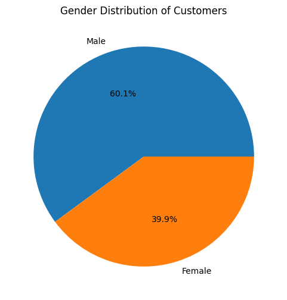

```python
plt.figure(figsize=(6, 6))
gender_counts = customer_df['Gender'].value_counts()
plt.pie(gender_counts, labels=gender_counts.index, autopct='%1.1f%%')
plt.title('Gender Distribution of Customers')
plt.show()
```

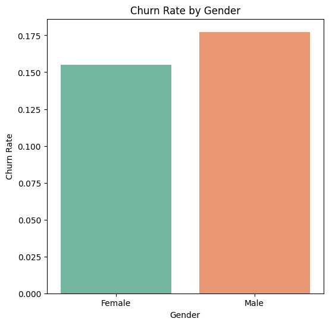

```python
gender_churn_rate = customer_df.groupby('Gender')['Churn'].mean()

plt.figure(figsize=(6, 6))
sns.barplot(x=gender_churn_rate.index, y=gender_churn_rate.values, palette='Set2')
plt.xlabel('Gender')
plt.ylabel('Churn Rate')
plt.title('Churn Rate by Gender')
plt.show()
```

### Tenure and Churn

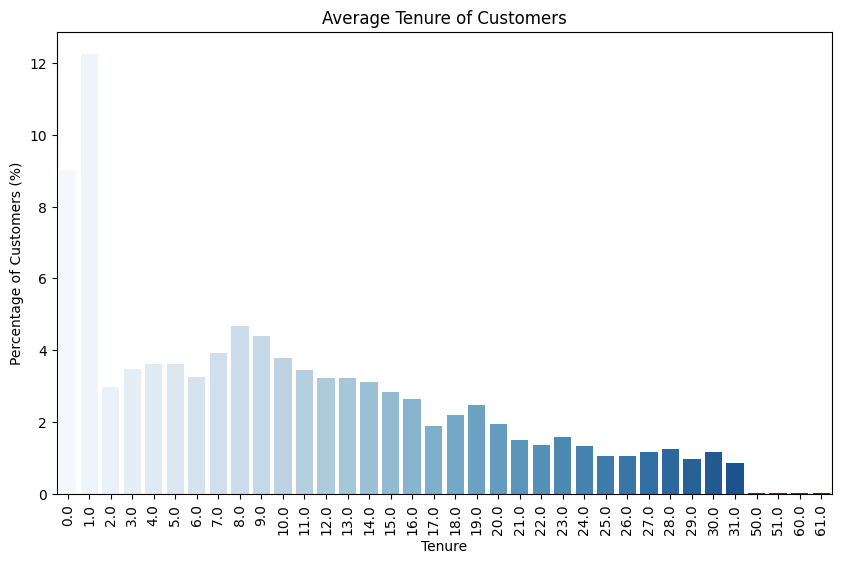

```python
plt.figure(figsize=(10, 6))
sns.barplot(x='Tenure', y='Tenure', data=customer_df, estimator=lambda x: len(x) / len(customer_df) * 100 , palette='Blues')
plt.xlabel('Tenure')
plt.ylabel('Percentage of Customers (%)')
plt.title('Average Tenure of Customers')
plt.xticks(rotation=90)
plt.show()
```

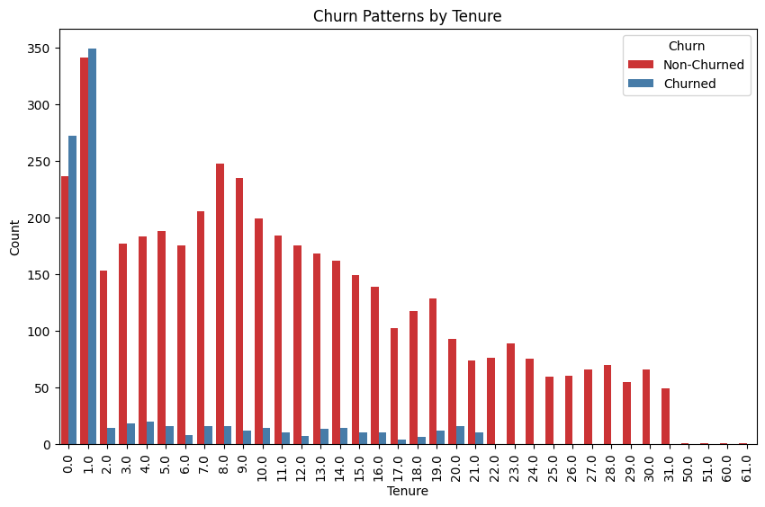

```python
plt.figure(figsize=(10, 6))
sns.countplot(x='Tenure', hue='Churn', data=customer_df, palette='Set1')
plt.xlabel('Tenure')
plt.ylabel('Count')
plt.title('Churn Patterns by Tenure')
plt.legend(title='Churn', labels=['Non-Churned', 'Churned'])
plt.xticks(rotation=90)
plt.show()
```

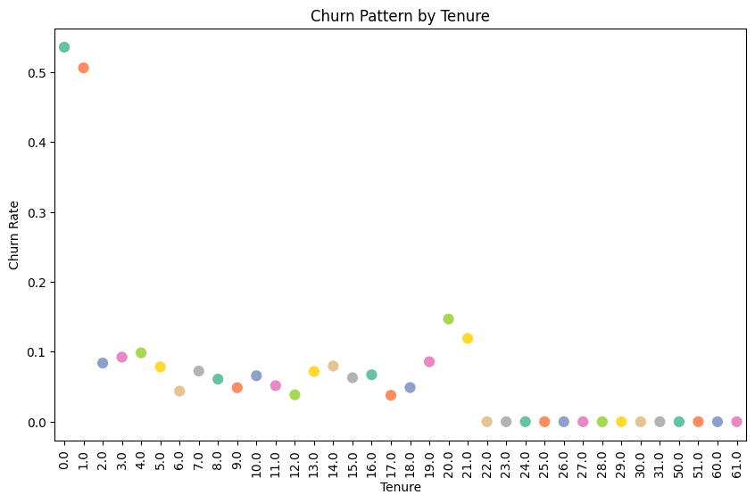

```python
plt.figure(figsize=(10, 6))
sns.pointplot(x='Tenure', y='Churn', data=customer_df, errorbar=None,  palette='Set2')
plt.xlabel('Tenure')
plt.ylabel('Churn Rate')
plt.title('Churn Pattern by Tenure')
plt.xticks(rotation=90)
plt.show()
```

### Days since Last Order and Churn

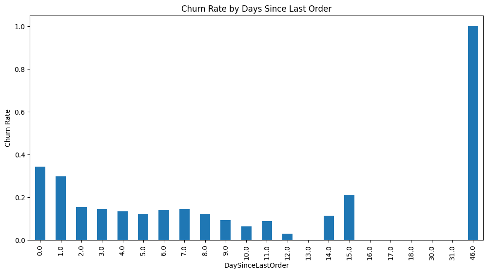

```python
# Group by 'DaySinceLastOrder' and calculate churn rate
churn_rate_by_days_since_last_order = customer_df.groupby('DaySinceLastOrder')['Churn'].mean()

# Plot
churn_rate_by_days_since_last_order.plot(kind='bar', figsize=(12,6))
plt.ylabel('Churn Rate')
plt.title('Churn Rate by Days Since Last Order')
plt.show()
```

### Cash back Amount and Churn

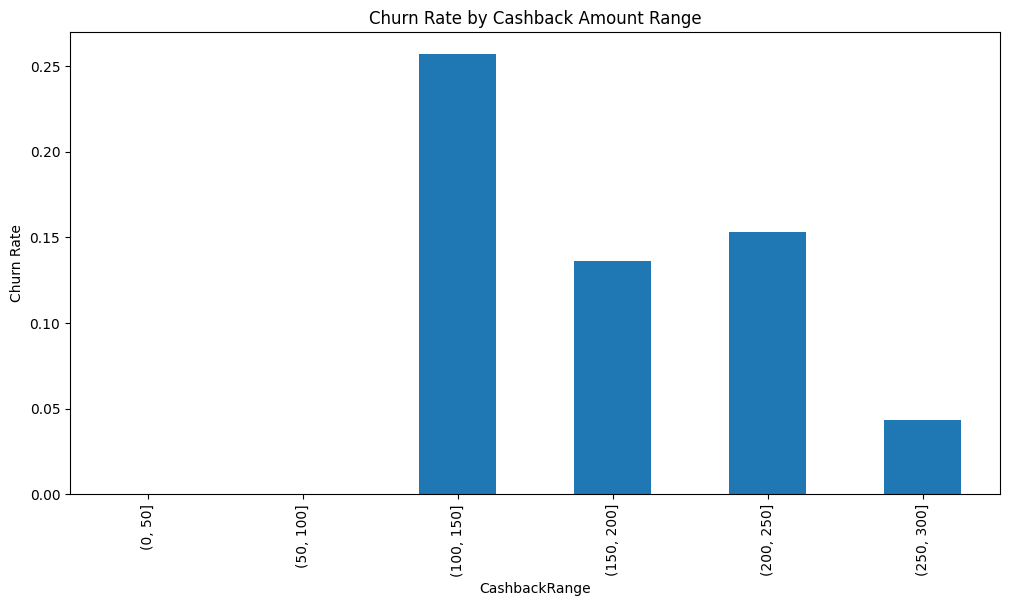

```python
# Define the ranges for cashback amounts
bins = [0, 50, 100, 150, 200, 250, 300]

# Create a new column in the DataFrame that indicates which range each customer's cashback amount falls into
customer_df['CashbackRange'] = pd.cut(customer_df['CashbackAmount'], bins)

# Group by the cashback range and calculate the churn rate
churn_rate_by_cashback_range = customer_df.groupby('CashbackRange')['Churn'].mean()

# Plot the churn rate for each cashback range
churn_rate_by_cashback_range.plot(kind='bar', figsize=(12,6))
plt.ylabel('Churn Rate')
plt.title('Churn Rate by Cashback Amount Range')
plt.show()
```

```python
customer_df.drop(columns =['CashbackRange'],  inplace=True)
```

### Complain and Churn

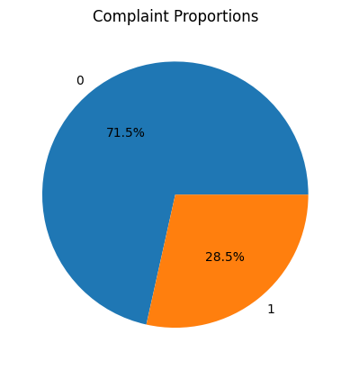

```python
# Calculate the proportion of complaints and non-complaints
complaint_proportions = customer_df['Complain'].value_counts(normalize=True)

# Create the pie chart
plt.pie(complaint_proportions, labels=complaint_proportions.index, autopct='%1.1f%%')
plt.title('Complaint Proportions')
plt.show()
```

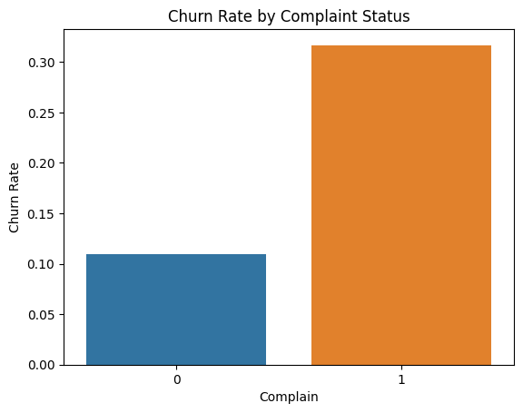

```python
# Calculate the churn rate for each complaint status
churn_rate_by_complaint = customer_df.groupby('Complain')['Churn'].mean()

# Create the bar plot
sns.barplot(x=churn_rate_by_complaint.index, y=churn_rate_by_complaint.values)
plt.xlabel('Complain')
plt.ylabel('Churn Rate')
plt.title('Churn Rate by Complaint Status')
plt.show()
```

- Shows the churn rate for customers who have made a complaint (Complain = 1) and those who haven’t (Complain = 0).
- Customers who have made a complaint (Complain = 1) have a higher churn rate
- Complaints are often a sign of customer dissatisfaction and hence could be a reason for customer churn

# 3. Data Preprocessing

## 3.1. Drop duplicates in the dataset

```python
customer_df.duplicated().sum()
```

```
0
```

## 3.2. Check for missing values in the dataset

```python
# Checking for missing values
customer_df.isnull().sum()
```

```
CustomerID                       0
Churn                            0
Tenure                         264
PreferredLoginDevice             0
CityTier                         0
WarehouseToHome                251
PreferredPaymentMode             0
Gender                           0
HourSpendOnApp                 255
NumberOfDeviceRegistered         0
PreferedOrderCat                 0
SatisfactionScore                0
MaritalStatus                    0
NumberOfAddress                  0
Complain                         0
OrderAmountHikeFromlastYear    265
CouponUsed                     256
OrderCount                     258
DaySinceLastOrder              307
CashbackAmount                   0
dtype: int64
```

```python
missing = pd.DataFrame(customer_df.isnull().sum()).reset_index()
missing.columns = ['Feature', 'Missing_Percent(%)']
missing['Missing_Percent(%)'] = missing['Missing_Percent(%)'].apply(lambda x: x / customer_df.shape[0] * 100)
missing.loc[missing['Missing_Percent(%)']>0,:]
```

|  | Feature | Missing_Percent(%) |
| --- | --- | --- |
| 2 | Tenure | 4.689165 |
| 5 | WarehouseToHome | 4.458259 |
| 8 | HourSpendOnApp | 4.529307 |
| 15 | OrderAmountHikeFromlastYear | 4.706927 |
| 16 | CouponUsed | 4.547069 |
| 17 | OrderCount | 4.582593 |
| 18 | DaySinceLastOrder | 5.452931 |

All the features have less than 5% missing values except DaysSinceLastOrder.

## 3.3. Handling with missing values in the dataset

```python
# Impute missing values for numerical columns with mean
numerical_cols = ['Tenure', 'WarehouseToHome', 'HourSpendOnApp', 'OrderAmountHikeFromlastYear', 'CouponUsed', 'OrderCount', 'DaySinceLastOrder']
for col in numerical_cols:
    customer_df[col] = customer_df[col].fillna(customer_df[col].mean())


# Verify missing values are handled
print(customer_df.isnull().sum())
```

```
CustomerID                     0
Churn                          0
Tenure                         0
PreferredLoginDevice           0
CityTier                       0
WarehouseToHome                0
PreferredPaymentMode           0
Gender                         0
HourSpendOnApp                 0
NumberOfDeviceRegistered       0
PreferedOrderCat               0
SatisfactionScore              0
MaritalStatus                  0
NumberOfAddress                0
Complain                       0
OrderAmountHikeFromlastYear    0
CouponUsed                     0
OrderCount                     0
DaySinceLastOrder              0
CashbackAmount                 0
dtype: int64
```

```python
customer_df.shape
```

```
(5630, 20)
```

## 3.4. Encode categorical variables into a numerical format using techniques like one-hot encoding or label encoding.

### 3.5.1. Data before the encode

```python
display(customer_df)
```

|  | CustomerID | Churn | Tenure | PreferredLoginDevice | CityTier | WarehouseToHome | PreferredPaymentMode | Gender | HourSpendOnApp | NumberOfDeviceRegistered | PreferedOrderCat | SatisfactionScore | MaritalStatus | NumberOfAddress | Complain | OrderAmountHikeFromlastYear | CouponUsed | OrderCount | DaySinceLastOrder | CashbackAmount |
| --- | --- | --- | --- | --- | --- | --- | --- | --- | --- | --- | --- | --- | --- | --- | --- | --- | --- | --- | --- | --- |
| 0 | 50001 | 1 | 4.000000 | Mobile Phone | 3 | 6.0 | Debit Card | Female | 3.000000 | 3 | Laptop & Accessory | 2 | Single | 9 | 1 | 11.0 | 1.0 | 1.0 | 5.000000 | 159.93 |
| 1 | 50002 | 1 | 10.189899 | Phone | 1 | 8.0 | UPI | Male | 3.000000 | 4 | Mobile | 3 | Single | 7 | 1 | 15.0 | 0.0 | 1.0 | 0.000000 | 120.90 |
| 2 | 50003 | 1 | 10.189899 | Phone | 1 | 30.0 | Debit Card | Male | 2.000000 | 4 | Mobile | 3 | Single | 6 | 1 | 14.0 | 0.0 | 1.0 | 3.000000 | 120.28 |
| 3 | 50004 | 1 | 0.000000 | Phone | 3 | 15.0 | Debit Card | Male | 2.000000 | 4 | Laptop & Accessory | 5 | Single | 8 | 0 | 23.0 | 0.0 | 1.0 | 3.000000 | 134.07 |
| 4 | 50005 | 1 | 0.000000 | Phone | 1 | 12.0 | CC | Male | 2.931535 | 3 | Mobile | 5 | Single | 3 | 0 | 11.0 | 1.0 | 1.0 | 3.000000 | 129.60 |
| ... | ... | ... | ... | ... | ... | ... | ... | ... | ... | ... | ... | ... | ... | ... | ... | ... | ... | ... | ... | ... |
| 5625 | 55626 | 0 | 10.000000 | Computer | 1 | 30.0 | Credit Card | Male | 3.000000 | 2 | Laptop & Accessory | 1 | Married | 6 | 0 | 18.0 | 1.0 | 2.0 | 4.000000 | 150.71 |
| 5626 | 55627 | 0 | 13.000000 | Mobile Phone | 1 | 13.0 | Credit Card | Male | 3.000000 | 5 | Fashion | 5 | Married | 6 | 0 | 16.0 | 1.0 | 2.0 | 4.543491 | 224.91 |
| 5627 | 55628 | 0 | 1.000000 | Mobile Phone | 1 | 11.0 | Debit Card | Male | 3.000000 | 2 | Laptop & Accessory | 4 | Married | 3 | 1 | 21.0 | 1.0 | 2.0 | 4.000000 | 186.42 |
| 5628 | 55629 | 0 | 23.000000 | Computer | 3 | 9.0 | Credit Card | Male | 4.000000 | 5 | Laptop & Accessory | 4 | Married | 4 | 0 | 15.0 | 2.0 | 2.0 | 9.000000 | 178.90 |
| 5629 | 55630 | 0 | 8.000000 | Mobile Phone | 1 | 15.0 | Credit Card | Male | 3.000000 | 2 | Laptop & Accessory | 3 | Married | 4 | 0 | 13.0 | 2.0 | 2.0 | 3.000000 | 169.04 |

5630 rows × 20 columns

```python
categorical_columns = customer_df.select_dtypes(include=['object']).columns
categorical_columns
```

```
Index(['PreferredLoginDevice', 'PreferredPaymentMode', 'Gender',
       'PreferedOrderCat', 'MaritalStatus'],
      dtype='object')
```

To encode categorical variables in customer_df dataset, we can use techniques like one-hot encoding or label encoding.

First, we will identify the categorical variables in this dataset:

1. PreferredLoginDevice
2. PreferredPaymentMode
3. Gender
4. PreferedOrderCat
5. MaritalStatus

```python
customer_df.PreferredLoginDevice.value_counts()
```

```
PreferredLoginDevice
Mobile Phone    2765
Computer        1634
Phone           1231
Name: count, dtype: int64
```

```python
customer_df.PreferredPaymentMode.value_counts()
```

```
PreferredPaymentMode
Debit Card          2314
Credit Card         1501
E wallet             614
UPI                  414
COD                  365
CC                   273
Cash on Delivery     149
Name: count, dtype: int64
```

```python
customer_df.Gender.value_counts()
```

```
Gender
Male      3384
Female    2246
Name: count, dtype: int64
```

```python
customer_df.PreferedOrderCat.value_counts()
```

```
PreferedOrderCat
Laptop & Accessory    2050
Mobile Phone          1271
Fashion                826
Mobile                 809
Grocery                410
Others                 264
Name: count, dtype: int64
```

```python
customer_df.MaritalStatus.value_counts()
```

```
MaritalStatus
Married     2986
Single      1796
Divorced     848
Name: count, dtype: int64
```

‘Gender’ is a binary categorical variable, using label encoding is simpler and doesn’t increase the dimensionality of the data

```python
from sklearn.preprocessing import LabelEncoder

# Initialize the LabelEncoder
label_encoder = LabelEncoder()

# Fit and transform the 'Gender' column
customer_df['Gender'] = label_encoder.fit_transform(customer_df['Gender'])
```

'PreferredLoginDevice' , 'PreferredPaymentMode' , 'PreferedOrderCat', 'MaritalStatus' are nominal categorical variables so we perform one-hot encoding

```python
from sklearn.preprocessing import OneHotEncoder

customer_df_encoded = pd.get_dummies(customer_df,columns = ['PreferredLoginDevice','PreferredPaymentMode','PreferedOrderCat','MaritalStatus'], drop_first = True)
customer_df_encoded = customer_df_encoded.astype(int)
customer_df_encoded.head()
```

|  | CustomerID | Churn | Tenure | CityTier | WarehouseToHome | Gender | HourSpendOnApp | NumberOfDeviceRegistered | SatisfactionScore | NumberOfAddress | ... | PreferredPaymentMode_Debit Card | PreferredPaymentMode_E wallet | PreferredPaymentMode_UPI | PreferedOrderCat_Grocery | PreferedOrderCat_Laptop & Accessory | PreferedOrderCat_Mobile | PreferedOrderCat_Mobile Phone | PreferedOrderCat_Others | MaritalStatus_Married | MaritalStatus_Single |
| --- | --- | --- | --- | --- | --- | --- | --- | --- | --- | --- | --- | --- | --- | --- | --- | --- | --- | --- | --- | --- | --- |
| 0 | 50001 | 1 | 4 | 3 | 6 | 0 | 3 | 3 | 2 | 9 | ... | 1 | 0 | 0 | 0 | 1 | 0 | 0 | 0 | 0 | 1 |
| 1 | 50002 | 1 | 10 | 1 | 8 | 1 | 3 | 4 | 3 | 7 | ... | 0 | 0 | 1 | 0 | 0 | 1 | 0 | 0 | 0 | 1 |
| 2 | 50003 | 1 | 10 | 1 | 30 | 1 | 2 | 4 | 3 | 6 | ... | 1 | 0 | 0 | 0 | 0 | 1 | 0 | 0 | 0 | 1 |
| 3 | 50004 | 1 | 0 | 3 | 15 | 1 | 2 | 4 | 5 | 8 | ... | 1 | 0 | 0 | 0 | 1 | 0 | 0 | 0 | 0 | 1 |
| 4 | 50005 | 1 | 0 | 1 | 12 | 1 | 2 | 3 | 5 | 3 | ... | 0 | 0 | 0 | 0 | 0 | 1 | 0 | 0 | 0 | 1 |

5 rows × 31 columns

### 3.5.2. Data after the encode

```python
display(customer_df_encoded)
```

|  | CustomerID | Churn | Tenure | CityTier | WarehouseToHome | Gender | HourSpendOnApp | NumberOfDeviceRegistered | SatisfactionScore | NumberOfAddress | ... | PreferredPaymentMode_Debit Card | PreferredPaymentMode_E wallet | PreferredPaymentMode_UPI | PreferedOrderCat_Grocery | PreferedOrderCat_Laptop & Accessory | PreferedOrderCat_Mobile | PreferedOrderCat_Mobile Phone | PreferedOrderCat_Others | MaritalStatus_Married | MaritalStatus_Single |
| --- | --- | --- | --- | --- | --- | --- | --- | --- | --- | --- | --- | --- | --- | --- | --- | --- | --- | --- | --- | --- | --- |
| 0 | 50001 | 1 | 4 | 3 | 6 | 0 | 3 | 3 | 2 | 9 | ... | 1 | 0 | 0 | 0 | 1 | 0 | 0 | 0 | 0 | 1 |
| 1 | 50002 | 1 | 10 | 1 | 8 | 1 | 3 | 4 | 3 | 7 | ... | 0 | 0 | 1 | 0 | 0 | 1 | 0 | 0 | 0 | 1 |
| 2 | 50003 | 1 | 10 | 1 | 30 | 1 | 2 | 4 | 3 | 6 | ... | 1 | 0 | 0 | 0 | 0 | 1 | 0 | 0 | 0 | 1 |
| 3 | 50004 | 1 | 0 | 3 | 15 | 1 | 2 | 4 | 5 | 8 | ... | 1 | 0 | 0 | 0 | 1 | 0 | 0 | 0 | 0 | 1 |
| 4 | 50005 | 1 | 0 | 1 | 12 | 1 | 2 | 3 | 5 | 3 | ... | 0 | 0 | 0 | 0 | 0 | 1 | 0 | 0 | 0 | 1 |
| ... | ... | ... | ... | ... | ... | ... | ... | ... | ... | ... | ... | ... | ... | ... | ... | ... | ... | ... | ... | ... | ... |
| 5625 | 55626 | 0 | 10 | 1 | 30 | 1 | 3 | 2 | 1 | 6 | ... | 0 | 0 | 0 | 0 | 1 | 0 | 0 | 0 | 1 | 0 |
| 5626 | 55627 | 0 | 13 | 1 | 13 | 1 | 3 | 5 | 5 | 6 | ... | 0 | 0 | 0 | 0 | 0 | 0 | 0 | 0 | 1 | 0 |
| 5627 | 55628 | 0 | 1 | 1 | 11 | 1 | 3 | 2 | 4 | 3 | ... | 1 | 0 | 0 | 0 | 1 | 0 | 0 | 0 | 1 | 0 |
| 5628 | 55629 | 0 | 23 | 3 | 9 | 1 | 4 | 5 | 4 | 4 | ... | 0 | 0 | 0 | 0 | 1 | 0 | 0 | 0 | 1 | 0 |
| 5629 | 55630 | 0 | 8 | 1 | 15 | 1 | 3 | 2 | 3 | 4 | ... | 0 | 0 | 0 | 0 | 1 | 0 | 0 | 0 | 1 | 0 |

5630 rows × 31 columns

```python
customer_df_encoded.head(100)
```

|  | CustomerID | Churn | Tenure | CityTier | WarehouseToHome | Gender | HourSpendOnApp | NumberOfDeviceRegistered | SatisfactionScore | NumberOfAddress | ... | PreferredPaymentMode_Debit Card | PreferredPaymentMode_E wallet | PreferredPaymentMode_UPI | PreferedOrderCat_Grocery | PreferedOrderCat_Laptop & Accessory | PreferedOrderCat_Mobile | PreferedOrderCat_Mobile Phone | PreferedOrderCat_Others | MaritalStatus_Married | MaritalStatus_Single |
| --- | --- | --- | --- | --- | --- | --- | --- | --- | --- | --- | --- | --- | --- | --- | --- | --- | --- | --- | --- | --- | --- |
| 0 | 50001 | 1 | 4 | 3 | 6 | 0 | 3 | 3 | 2 | 9 | ... | 1 | 0 | 0 | 0 | 1 | 0 | 0 | 0 | 0 | 1 |
| 1 | 50002 | 1 | 10 | 1 | 8 | 1 | 3 | 4 | 3 | 7 | ... | 0 | 0 | 1 | 0 | 0 | 1 | 0 | 0 | 0 | 1 |
| 2 | 50003 | 1 | 10 | 1 | 30 | 1 | 2 | 4 | 3 | 6 | ... | 1 | 0 | 0 | 0 | 0 | 1 | 0 | 0 | 0 | 1 |
| 3 | 50004 | 1 | 0 | 3 | 15 | 1 | 2 | 4 | 5 | 8 | ... | 1 | 0 | 0 | 0 | 1 | 0 | 0 | 0 | 0 | 1 |
| 4 | 50005 | 1 | 0 | 1 | 12 | 1 | 2 | 3 | 5 | 3 | ... | 0 | 0 | 0 | 0 | 0 | 1 | 0 | 0 | 0 | 1 |
| ... | ... | ... | ... | ... | ... | ... | ... | ... | ... | ... | ... | ... | ... | ... | ... | ... | ... | ... | ... | ... | ... |
| 95 | 50096 | 0 | 9 | 1 | 11 | 1 | 3 | 3 | 4 | 9 | ... | 1 | 0 | 0 | 0 | 1 | 0 | 0 | 0 | 0 | 1 |
| 96 | 50097 | 0 | 6 | 1 | 15 | 0 | 2 | 4 | 4 | 7 | ... | 0 | 0 | 0 | 0 | 0 | 1 | 0 | 0 | 0 | 0 |
| 97 | 50098 | 0 | 10 | 1 | 17 | 1 | 2 | 3 | 2 | 2 | ... | 0 | 0 | 1 | 0 | 0 | 0 | 0 | 0 | 1 | 0 |
| 98 | 50099 | 0 | 11 | 3 | 9 | 1 | 3 | 3 | 3 | 1 | ... | 1 | 0 | 0 | 0 | 0 | 0 | 0 | 0 | 1 | 0 |
| 99 | 50100 | 0 | 4 | 1 | 6 | 1 | 2 | 5 | 3 | 1 | ... | 0 | 0 | 0 | 0 | 1 | 0 | 0 | 0 | 0 | 0 |

100 rows × 31 columns

## 3.6. Scale numerical features to ensure they have similar ranges, which can improve the performance of ML algorithm.

To scale numerical features, you can use various methods such as Min-Max Scaling or Standardization.

### 3.6.1. Min-Max Scaling

Min-Max Scaling is useful when you need the data to be bounded within a specific range.

If our features to be within a bounded range, Min-Max Scaling is preferable.

```python
import pandas as pd
from sklearn.preprocessing import MinMaxScaler, StandardScaler
import joblib



# Min-Max Scaling
min_max_scaler = MinMaxScaler()
columns_to_scale = ['Tenure', 'CityTier', 'WarehouseToHome', 'HourSpendOnApp', 'NumberOfDeviceRegistered', 'SatisfactionScore', 'NumberOfAddress']
customer_df_encoded[columns_to_scale] = min_max_scaler.fit_transform(customer_df_encoded[columns_to_scale])

customer_df_encoded_min_max = customer_df_encoded

scaler_file = "min_max_scaler.pkl"
joblib.dump(min_max_scaler, scaler_file)
print("\nDataFrame after Min-Max Scaling:")
customer_df_encoded_min_max.head(5)
```

```
DataFrame after Min-Max Scaling:
```

|  | CustomerID | Churn | Tenure | CityTier | WarehouseToHome | Gender | HourSpendOnApp | NumberOfDeviceRegistered | SatisfactionScore | NumberOfAddress | ... | PreferredPaymentMode_Debit Card | PreferredPaymentMode_E wallet | PreferredPaymentMode_UPI | PreferedOrderCat_Grocery | PreferedOrderCat_Laptop & Accessory | PreferedOrderCat_Mobile | PreferedOrderCat_Mobile Phone | PreferedOrderCat_Others | MaritalStatus_Married | MaritalStatus_Single |
| --- | --- | --- | --- | --- | --- | --- | --- | --- | --- | --- | --- | --- | --- | --- | --- | --- | --- | --- | --- | --- | --- |
| 0 | 50001 | 1 | 0.065574 | 1.0 | 0.008197 | 0 | 0.6 | 0.4 | 0.25 | 0.380952 | ... | 1 | 0 | 0 | 0 | 1 | 0 | 0 | 0 | 0 | 1 |
| 1 | 50002 | 1 | 0.163934 | 0.0 | 0.024590 | 1 | 0.6 | 0.6 | 0.50 | 0.285714 | ... | 0 | 0 | 1 | 0 | 0 | 1 | 0 | 0 | 0 | 1 |
| 2 | 50003 | 1 | 0.163934 | 0.0 | 0.204918 | 1 | 0.4 | 0.6 | 0.50 | 0.238095 | ... | 1 | 0 | 0 | 0 | 0 | 1 | 0 | 0 | 0 | 1 |
| 3 | 50004 | 1 | 0.000000 | 1.0 | 0.081967 | 1 | 0.4 | 0.6 | 1.00 | 0.333333 | ... | 1 | 0 | 0 | 0 | 1 | 0 | 0 | 0 | 0 | 1 |
| 4 | 50005 | 1 | 0.000000 | 0.0 | 0.057377 | 1 | 0.4 | 0.4 | 1.00 | 0.095238 | ... | 0 | 0 | 0 | 0 | 0 | 1 | 0 | 0 | 0 | 1 |

5 rows × 31 columns

### 3.6.2. Standardization

Standardization scales the data to have a mean of 0 and a standard deviation of 1.

If our dataset contains significant outliers or if we ar going to use models that benefit from normally distributed data, Standardization might be more suitable.

```python
# Standardization
standard_scaler = StandardScaler()
customer_df_encoded[columns_to_scale] = standard_scaler.fit_transform(customer_df_encoded[columns_to_scale])

customer_df_encoded_scal = customer_df_encoded

print("\nDataFrame after Standardization:")
customer_df_encoded_scal.head(5)
```

```
DataFrame after Standardization:
```

|  | CustomerID | Churn | Tenure | CityTier | WarehouseToHome | Gender | HourSpendOnApp | NumberOfDeviceRegistered | SatisfactionScore | NumberOfAddress | ... | PreferredPaymentMode_Debit Card | PreferredPaymentMode_E wallet | PreferredPaymentMode_UPI | PreferedOrderCat_Grocery | PreferedOrderCat_Laptop & Accessory | PreferedOrderCat_Mobile | PreferedOrderCat_Mobile Phone | PreferedOrderCat_Others | MaritalStatus_Married | MaritalStatus_Single |
| --- | --- | --- | --- | --- | --- | --- | --- | --- | --- | --- | --- | --- | --- | --- | --- | --- | --- | --- | --- | --- | --- |
| 0 | 50001 | 1 | -0.739927 | 1.469771 | -1.152525 | 0 | 0.151287 | -0.67290 | -0.772992 | 1.852616 | ... | 1 | 0 | 0 | 0 | 1 | 0 | 0 | 0 | 0 | 1 |
| 1 | 50002 | 1 | -0.021667 | -0.715286 | -0.912700 | 1 | 0.151287 | 0.30375 | -0.048392 | 1.078430 | ... | 0 | 0 | 1 | 0 | 0 | 1 | 0 | 0 | 0 | 1 |
| 2 | 50003 | 1 | -0.021667 | -0.715286 | 1.725380 | 1 | -1.215882 | 0.30375 | -0.048392 | 0.691336 | ... | 1 | 0 | 0 | 0 | 0 | 1 | 0 | 0 | 0 | 1 |
| 3 | 50004 | 1 | -1.218767 | 1.469771 | -0.073311 | 1 | -1.215882 | 0.30375 | 1.400807 | 1.465523 | ... | 1 | 0 | 0 | 0 | 1 | 0 | 0 | 0 | 0 | 1 |
| 4 | 50005 | 1 | -1.218767 | -0.715286 | -0.433049 | 1 | -1.215882 | -0.67290 | 1.400807 | -0.469944 | ... | 0 | 0 | 0 | 0 | 0 | 1 | 0 | 0 | 0 | 1 |

5 rows × 31 columns

## 3.7. Identify which features are most relevant for predicting customer attrition and determine strategies that were sure to work to improve retention

To identify the most relevant features for predicting customer attrition, we can use various techniques such as:

- Correlation Analysis: To see how features are correlated with churn.
- Feature Importance from Models: Using models like Random Forest or Gradient Boosting that provide feature importance scores.
- Chi-Square Test: For categorical features.

Observation: **Churn**, also known as **customer attrition**, refers to the phenomenon where customers stop using a company's products or services. It is a critical metric for businesses as it directly impacts revenue and growth. Understanding and reducing churn is essential for maintaining a stable customer base and ensuring long-term profitability.

### 3.7.1. Correlation Analysis

```
Correlation of features with Churn:
Churn                                    1.000000
Complain                                 0.250188
MaritalStatus_Single                     0.180847
PreferedOrderCat_Mobile Phone            0.154387
PreferedOrderCat_Mobile                  0.113364
NumberOfDeviceRegistered                 0.107939
SatisfactionScore                        0.105481
CityTier                                 0.084703
PreferredPaymentMode_COD                 0.083933
PreferredLoginDevice_Phone               0.078916
WarehouseToHome                          0.071968
PreferredPaymentMode_E wallet            0.055751
NumberOfAddress                          0.043931
Gender                                   0.029264
HourSpendOnApp                           0.008373
PreferredPaymentMode_UPI                 0.004163
CouponUsed                              -0.001430
PreferredPaymentMode_Cash on Delivery   -0.006178
OrderAmountHikeFromlastYear             -0.007075
CustomerID                              -0.019083
OrderCount                              -0.028308
PreferredPaymentMode_Debit Card         -0.032453
PreferedOrderCat_Others                 -0.054903
PreferredPaymentMode_Credit Card        -0.064131
PreferedOrderCat_Grocery                -0.089575
PreferredLoginDevice_Mobile Phone       -0.111639
PreferedOrderCat_Laptop & Accessory     -0.133353
MaritalStatus_Married                   -0.151024
CashbackAmount                          -0.154087
DaySinceLastOrder                       -0.156225
Tenure                                  -0.335903
Name: Churn, dtype: float64
```

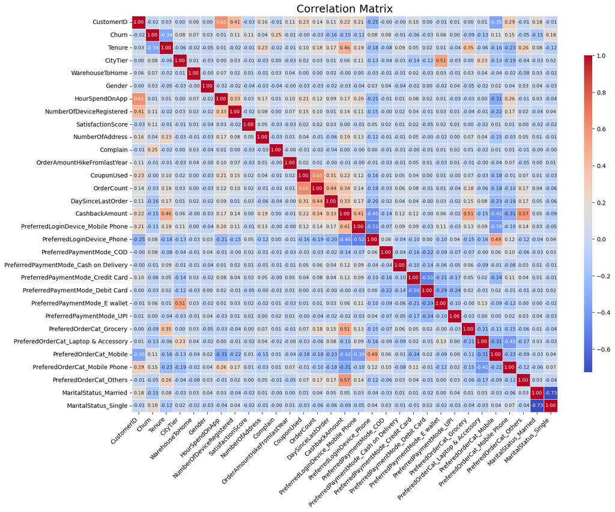

```python
import pandas as pd
import seaborn as sns
import matplotlib.pyplot as plt

# Calculate the correlation matrix
correlation_matrix = customer_df_encoded_min_max.corr()

# Extract correlation with target variable 'Churn'
correlation_with_churn = correlation_matrix['Churn'].sort_values(ascending=False)

print("Correlation of features with Churn:")
print(correlation_with_churn)

# Plotting the correlation matrix for visualization

plt.figure(figsize=(16, 12))

# Generate a heatmap
sns.heatmap(correlation_matrix,
            annot=True,
            cmap='coolwarm',
            fmt='.2f',
            linewidths=0.5,
            annot_kws={"size": 8},  # Adjust the annotation font size
            cbar_kws={"shrink": 0.8, "aspect": 40})  # Adjust color bar size

# Set the title with a larger font size
plt.title('Correlation Matrix', fontsize=18)

# Adjust the x and y axis labels font size
plt.xticks(fontsize=10, rotation=45, ha='right')
plt.yticks(fontsize=10)

# Display the heatmap
plt.show()
```

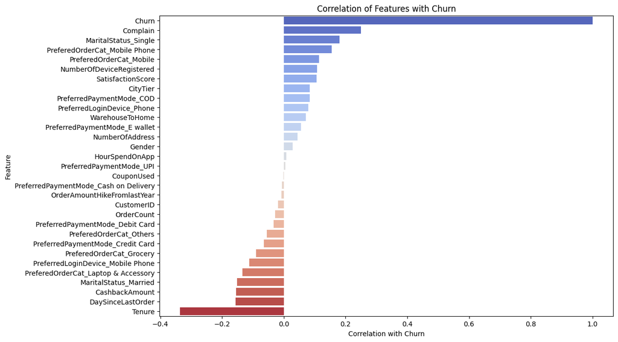

```python
import pandas as pd
import seaborn as sns
import matplotlib.pyplot as plt


correlation_df = pd.DataFrame(list(correlation_with_churn.items()), columns=['Feature', 'Correlation with Churn'])
correlation_df = correlation_df.sort_values(by='Correlation with Churn', ascending=False)

# Plotting
plt.figure(figsize=(12, 8))
sns.barplot(x='Correlation with Churn', y='Feature', data=correlation_df, palette='coolwarm')
plt.title('Correlation of Features with Churn')
plt.xlabel('Correlation with Churn')
plt.ylabel('Feature')
plt.show()
```

Based on the correlation analysis, we can see which features have the highest positive and negative correlations with customer churn. Here are some insights and strategies based on these correlations:

Key Features Positively Correlated with Churn

- Complain (0.250188): Customers who have complained are more likely to churn.
- MaritalStatus_Single (0.180847): Single customers are more likely to churn compared to married ones.
- PreferedOrderCat_Mobile Phone (0.154387): Customers who prefer ordering mobile phones have a higher churn rate.

Key Features Negatively Correlated with Churn

- Tenure (-0.335903): Longer tenure is associated with lower churn, indicating that long-term customers are less likely to leave.
- DaySinceLastOrder (-0.156225): More days since the last order are associated with lower churn.
- CashbackAmount (-0.154087): Higher cashback amounts are associated with lower churn.

### 3.7.2. Feature Importance from Models: Using Random Forest

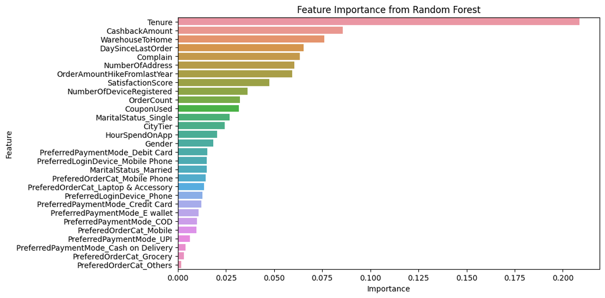

```python
import pandas as pd
import seaborn as sns
import matplotlib.pyplot as plt
from sklearn.ensemble import RandomForestClassifier
from sklearn.model_selection import train_test_split
from sklearn.feature_selection import chi2
from sklearn.preprocessing import MinMaxScaler

# Assuming customer_df_encoded is your DataFrame
# Prepare the data
X = customer_df_encoded.drop(columns=['Churn', 'CustomerID'])
y = customer_df_encoded['Churn']

# Normalize the numerical features for chi-square test
scaler = MinMaxScaler()
X_scaled = scaler.fit_transform(X)

# Split the data into training and testing sets
X_train, X_test, y_train, y_test = train_test_split(X, y, test_size=0.3, random_state=42)

# Feature importance using Random Forest
rf = RandomForestClassifier(random_state=42)
rf.fit(X_train, y_train)
importances = rf.feature_importances_

# Creating a DataFrame for visualization
feature_importance_df = pd.DataFrame({
    'Feature': X.columns,
    'Importance': importances
}).sort_values(by='Importance', ascending=False)

# Plotting feature importance
plt.figure(figsize=(10, 6))
sns.barplot(x='Importance', y='Feature', data=feature_importance_df)
plt.title('Feature Importance from Random Forest')
plt.show()
```

Feature Importance from Random Forest:

- Tenure is the most important feature, indicating that how long a customer has been with the company is a strong predictor of whether they will churn.
- CashbackAmount and WarehouseToHome are also highly important, suggesting that financial incentives and delivery times significantly impact customer retention.
- Other important features include DaySinceLastOrder, Complain, NumberOfAddress, and SatisfactionScore.

### 3.7.3. Chi-Square Test: For categorical features.

Our categorical features are:

1. Complain: Whether a customer has complained (binary categorical).
2. MaritalStatus_Single: Whether a customer is single (binary categorical).
3. MaritalStatus_Married: Whether a customer is married (binary categorical).
4. PreferredPaymentMode:
- PreferredPaymentMode_COD: Cash on delivery (binary categorical).
- PreferredPaymentMode_Credit Card: Credit card (binary categorical).
- PreferredPaymentMode_Debit Card: Debit card (binary categorical).
- PreferredPaymentMode_E wallet: E-wallet (binary categorical).
- PreferredPaymentMode_Cash on Delivery: Cash on delivery (binary categorical).

PreferredPaymentMode_UPI: UPI (binary categorical). 5. PreferedOrderCat:

- PreferedOrderCat_Grocery: Grocery (binary categorical).
- PreferedOrderCat_Laptop & Accessory: Laptop and accessory (binary categorical).
- PreferedOrderCat_Mobile: Mobile (binary categorical).
- PreferedOrderCat_Mobile Phone: Mobile phone (binary categorical).
- PreferedOrderCat_Others: Others (binary categorical).
6. PreferredLoginDevice:
- PreferredLoginDevice_Mobile Phone: Mobile phone (binary categorical).
- PreferredLoginDevice_Phone: Phone (binary categorical).

```python
# Chi-square test for categorical features
chi_scores = chi2(X_scaled, y)
chi2_df = pd.DataFrame({
    'Feature': X.columns,
    'Chi2': chi_scores[0],
    'p-value': chi_scores[1]
}).sort_values(by='Chi2', ascending=False)

print("\nChi-square test results:")
print(chi2_df)
```

```
Chi-square test results:
                                  Feature        Chi2       p-value
8                                Complain  252.004099  9.495870e-57
28                   MaritalStatus_Single  125.392983  4.175092e-29
25          PreferedOrderCat_Mobile Phone  103.898547  2.129455e-24
0                                  Tenure   71.376653  2.951439e-17
23    PreferedOrderCat_Laptop & Accessory   63.663401  1.476015e-15
24                PreferedOrderCat_Mobile   61.956169  3.511878e-15
27                  MaritalStatus_Married   60.304991  8.124113e-15
22               PreferedOrderCat_Grocery   41.883820  9.686082e-11
16               PreferredPaymentMode_COD   37.090298  1.127835e-09
14      PreferredLoginDevice_Mobile Phone   35.707123  2.293240e-09
15             PreferredLoginDevice_Phone   27.395656  1.658033e-07
1                                CityTier   25.844331  3.700900e-07
18       PreferredPaymentMode_Credit Card   16.981775  3.774035e-05
```

[output cut: 16 more lines]

1. Complain:
- Chi2 Value: 252.004099
- p-value: 9.495870e-57
- Insight: This feature has the highest Chi2 value and an extremely low p-value, indicating a very strong association with churn. Customers who have complained are significantly more likely to churn.
2. MaritalStatus_Single:
- Chi2 Value: 125.392983
- p-value: 4.175092e-29
- Insight: Single customers are significantly more likely to churn compared to married customers.
3. PreferedOrderCat_Mobile Phone:
- Chi2 Value: 103.898547
- p-value: 2.129455e-24
- Insight: Customers who prefer ordering mobile phones are significantly more likely to churn.
4. Tenure:
- Chi2 Value: 71.376653
- p-value: 2.951439e-17
- Insight: Longer tenure is significantly associated with lower churn.

### 3.7.4. Synthesize the insights from each method.

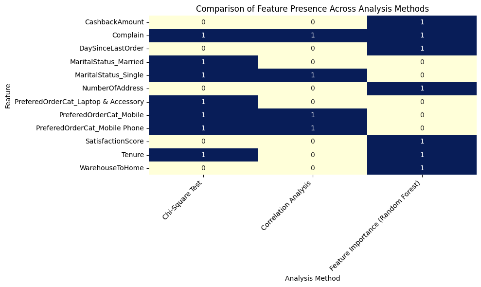

```python
import pandas as pd
import seaborn as sns
import matplotlib.pyplot as plt

# Data based on the insights provided
data = {
    'Feature': [
        'Complain',
        'MaritalStatus_Single',
        'PreferedOrderCat_Mobile Phone',
        'PreferedOrderCat_Mobile',
        'Tenure',
        'CashbackAmount',
        'WarehouseToHome',
        'DaySinceLastOrder',
        'NumberOfAddress',
        'SatisfactionScore',
        'PreferedOrderCat_Laptop & Accessory',
        'MaritalStatus_Married'
    ],
    'Correlation Analysis': [
        'Yes',
        'Yes',
        'Yes',
        'Yes',
        'No',
        'No',
        'No',
        'No',
        'No',
        'No',
        'No',
        'No'
    ],
    'Feature Importance (Random Forest)': [
        'Yes',
        'No',
        'No',
        'No',
        'Yes',
        'Yes',
        'Yes',
        'Yes',
        'Yes',
        'Yes',
        'No',
        'No'
    ],
    'Chi-Square Test': [
        'Yes',
        'Yes',
        'Yes',
        'Yes',
        'Yes',
        'No',
        'No',
        'No',
        'No',
        'No',
        'Yes',
        'Yes'
    ]
}

# Create DataFrame
comparison_df = pd.DataFrame(data)

# Define a function to apply color
def highlight_yes(s):
    color = 'background-color: lightgreen'
    return [color if v == 'Yes' else '' for v in s]

# Apply the function to the DataFrame
styled_comparison_df = comparison_df.style.apply(highlight_yes, axis=1)

# Display the styled DataFrame
styled_comparison_df

# Plot the comparison table
plt.figure(figsize=(10, 6))

# Convert DataFrame to long format for better visualization
comparison_long = pd.melt(comparison_df, id_vars=['Feature'], var_name='Analysis Method', value_name='Presence')

# Create a pivot table for the heatmap
pivot_table = comparison_long.pivot(index='Feature', columns='Analysis Method', values='Presence')

# Replace 'Yes' and 'No' with 1 and 0 for heatmap visualization
pivot_table = pivot_table.replace({'Yes': 1, 'No': 0})

# Plot the heatmap
sns.heatmap(pivot_table, annot=True, fmt='d', cmap='YlGnBu', cbar=False)
plt.title('Comparison of Feature Presence Across Analysis Methods')
plt.xlabel('Analysis Method')
plt.ylabel('Feature')
plt.xticks(rotation=45, ha='right')
plt.tight_layout()
plt.show()
```

#### Insights and Recommendations:

Based on this comparison, the most impactful features across all analyses are:

- Complain: This feature consistently shows up across all three methods, indicating a strong association with churn.
- Tenure: Significant in both the Random Forest feature importance and Chi-Square test, indicating longer tenure reduces churn.
- MaritalStatus_Single: Significant in correlation analysis and Chi-Square test, indicating single customers are more likely to churn.
- PreferedOrderCat_Mobile Phone: Shows up in correlation analysis and Chi-Square test, indicating customers who prefer mobile phones are more likely to churn.
- PreferedOrderCat_Mobile: Similar to Mobile Phone, this feature appears in both correlation and Chi-Square tests.

# 4. Choose appropriate machine learning algorithms for customer attrition.

```python
customer_df_encoded_min_max.columns
```

```
Index(['CustomerID', 'Churn', 'Tenure', 'CityTier', 'WarehouseToHome',
       'Gender', 'HourSpendOnApp', 'NumberOfDeviceRegistered',
       'SatisfactionScore', 'NumberOfAddress', 'Complain',
       'OrderAmountHikeFromlastYear', 'CouponUsed', 'OrderCount',
       'DaySinceLastOrder', 'CashbackAmount',
       'PreferredLoginDevice_Mobile Phone', 'PreferredLoginDevice_Phone',
       'PreferredPaymentMode_COD', 'PreferredPaymentMode_Cash on Delivery',
       'PreferredPaymentMode_Credit Card', 'PreferredPaymentMode_Debit Card',
       'PreferredPaymentMode_E wallet', 'PreferredPaymentMode_UPI',
       'PreferedOrderCat_Grocery', 'PreferedOrderCat_Laptop & Accessory',
       'PreferedOrderCat_Mobile', 'PreferedOrderCat_Mobile Phone',
       'PreferedOrderCat_Others', 'MaritalStatus_Married',
       'MaritalStatus_Single'],
      dtype='object')
```

```
Logistic Regression Accuracy: 0.88
```

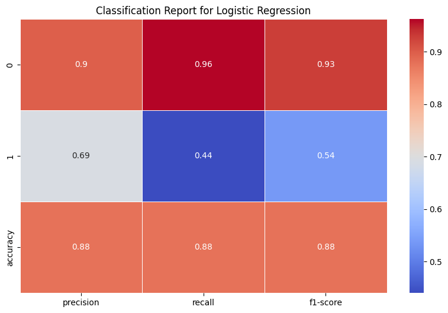

```
Decision Tree Accuracy: 0.93
```

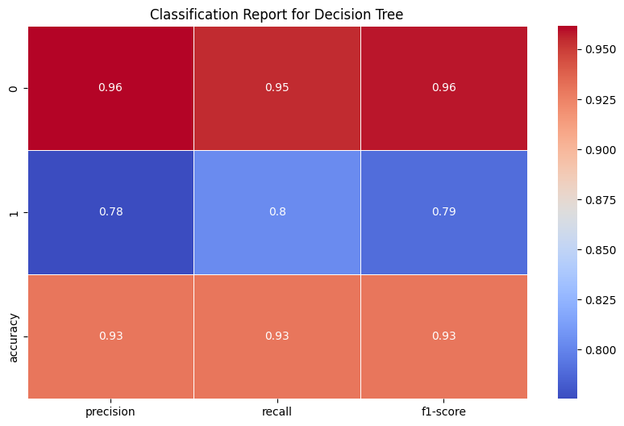

```
Random Forest Accuracy: 0.94
```

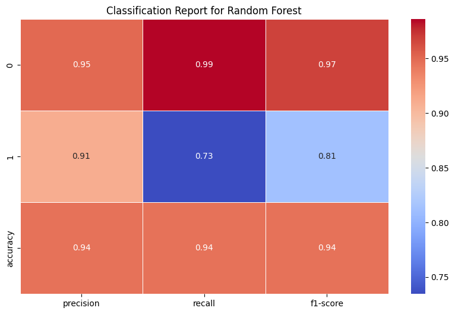

```
Gradient Boosting Accuracy: 0.91
```

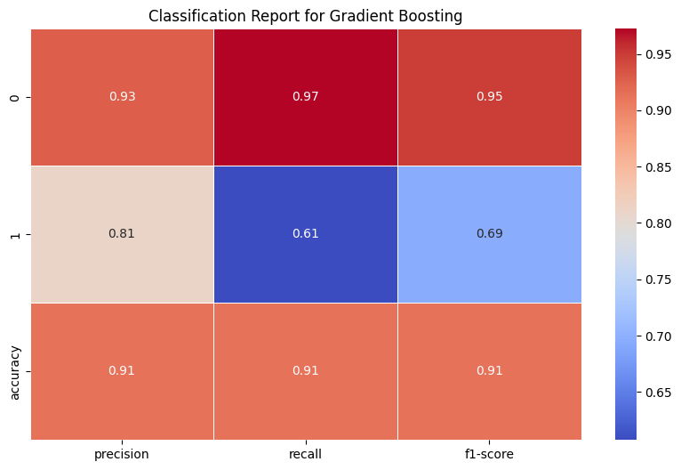

```
SVM Accuracy: 0.84
```

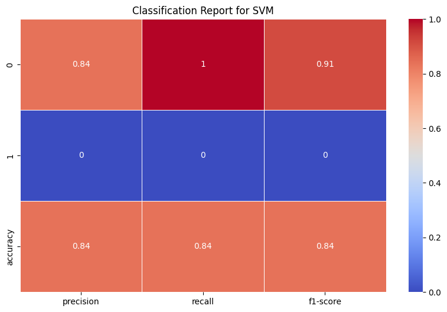

```
KNN Accuracy: 0.81
```

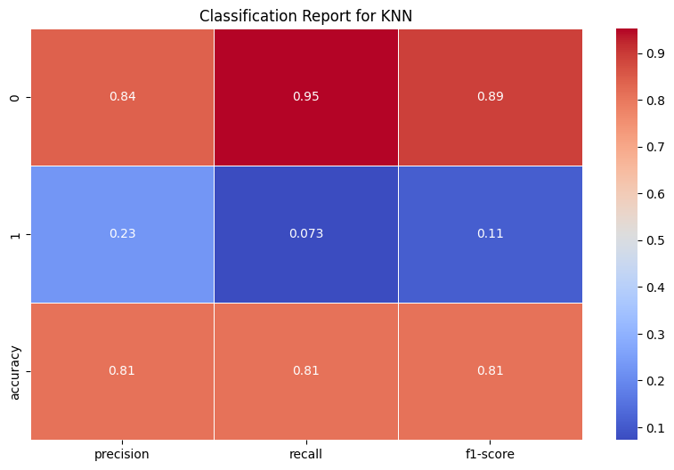

```
Model Comparison:
                     Accuracy
Logistic Regression  0.876850
Decision Tree        0.930136
Random Forest        0.944938
Gradient Boosting    0.912966
SVM                  0.837182
KNN                  0.809355
```

```python
import pandas as pd
from sklearn.model_selection import train_test_split, cross_val_score
from sklearn.linear_model import LogisticRegression
from sklearn.tree import DecisionTreeClassifier
from sklearn.ensemble import RandomForestClassifier, GradientBoostingClassifier
from sklearn.svm import SVC
from sklearn.neighbors import KNeighborsClassifier
from sklearn.metrics import accuracy_score, classification_report


# Prepare the data
X = customer_df_encoded_min_max.drop(columns=['Churn'])  # Replace 'Churn' with the actual target column name if different
y = customer_df_encoded_min_max['Churn']  # Replace 'Churn' with the actual target column name if different

# Split the data into training and testing sets
X_train, X_test, y_train, y_test = train_test_split(X, y, test_size=0.3, random_state=42)

# Initialize models
models = {
    'Logistic Regression': LogisticRegression(),
    'Decision Tree': DecisionTreeClassifier(),
    'Random Forest': RandomForestClassifier(),
    'Gradient Boosting': GradientBoostingClassifier(),
    'SVM': SVC(probability=True),
    'KNN': KNeighborsClassifier()
}

# Evaluate models
results = {}
for model_name, model in models.items():
    model.fit(X_train, y_train)
    y_pred = model.predict(X_test)
    accuracy = accuracy_score(y_test, y_pred)
    results[model_name] = accuracy
    print(f"{model_name} Accuracy: {accuracy:.2f}")
    report = classification_report(y_test, y_pred,output_dict=True)
    report_df = pd.DataFrame(report).transpose()
    report_df = report_df.drop(['macro avg', 'weighted avg'])
    report_df = report_df.drop(columns=['support'])
    # Plot the heatmap
    plt.figure(figsize=(10, 6))
    sns.heatmap(report_df, annot=True, cmap='coolwarm', linewidths=.5)
    plt.title(f'Classification Report for {model_name}')
    plt.show()

# Display results
results_df = pd.DataFrame.from_dict(results, orient='index', columns=['Accuracy'])
print("\nModel Comparison:")
print(results_df)
```

```python
# Convert the results dictionary to a DataFrame
results_df = pd.DataFrame.from_dict(results, orient='index', columns=['Accuracy'])

# Optional: Style the DataFrame for better visualization
styled_results_df = results_df.style.format({
    'Accuracy': "{:.6f}"
}).background_gradient(cmap='Blues', subset=['Accuracy'])

# Display the styled DataFrame
styled_results_df
```

[output not shown]

The table above shows that the Random Forest model has the highest accuracy, followed by the Decision Tree and Gradient Boosting models.

```python
rf_model = RandomForestClassifier(n_estimators=100, random_state=42)
rf_model.fit(X_train, y_train)
```

```
RandomForestClassifier(random_state=42)
```

```python
y_pred_train = rf_model.predict(X_train)
training_accuracy = accuracy_score(y_train, y_pred_train)
print(f"Random Forest Training Accuracy: {training_accuracy:.2f}")
training_report = classification_report(y_train, y_pred_train)
print(training_report)
```

```
Random Forest Training Accuracy: 1.00
              precision    recall  f1-score   support

           0       1.00      1.00      1.00      3268
           1       1.00      1.00      1.00       673

    accuracy                           1.00      3941
   macro avg       1.00      1.00      1.00      3941
weighted avg       1.00      1.00      1.00      3941
```

```
Random Forest Testing Accuracy: 0.95
```

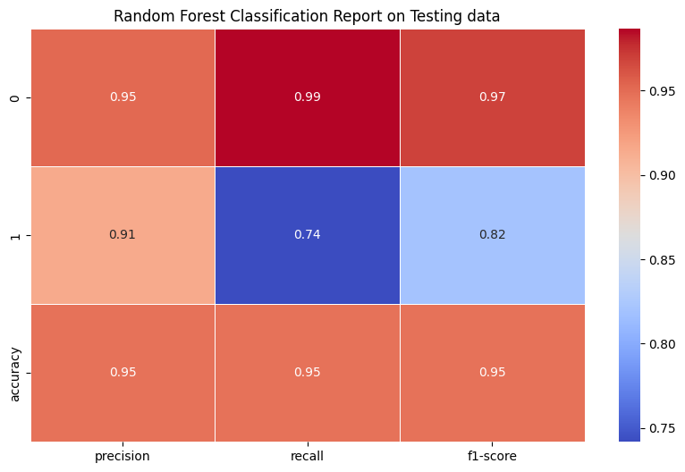

```python
y_pred_test = rf_model.predict(X_test)
testing_accuracy = accuracy_score(y_test, y_pred_test)
print(f"Random Forest Testing Accuracy: {testing_accuracy:.2f}")
testing_report = classification_report(y_test, y_pred_test,output_dict=True)
report_df = pd.DataFrame(testing_report).transpose()
report_df = report_df.drop(['macro avg', 'weighted avg'])
report_df = report_df.drop(columns=['support'])
# Plot the heatmap
plt.figure(figsize=(10, 6))
sns.heatmap(report_df, annot=True, cmap='coolwarm', linewidths=.5)
plt.title(f'Random Forest Classification Report on Testing data')
plt.show()
```

```python
import joblib
# Save the trained model to a file
joblib_file = "random_forest_model.pkl"
joblib.dump(rf_model, joblib_file)
```

```
['random_forest_model.pkl']
```

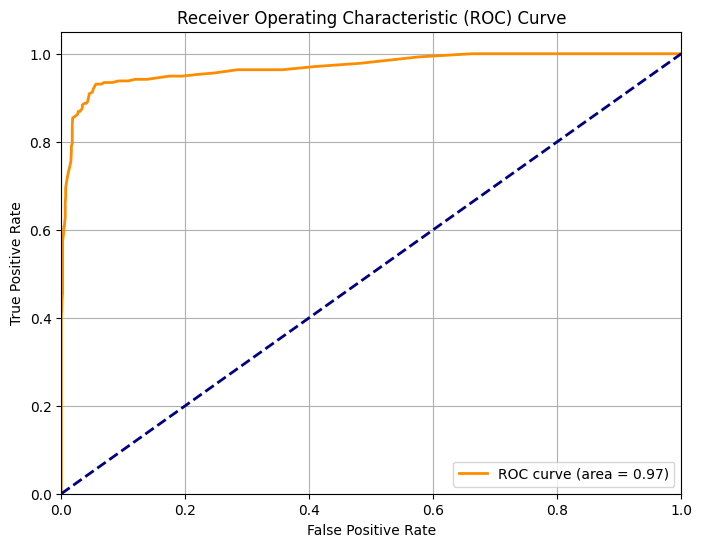

```python
from sklearn.metrics import roc_curve, auc
# Predict probabilities on test set
y_prob = rf_model.predict_proba(X_test)[:, 1]

# Compute ROC curve and ROC area for each class
fpr, tpr, _ = roc_curve(y_test, y_prob)
roc_auc = auc(fpr, tpr)

# Plot ROC curve
plt.figure(figsize=(8, 6))
plt.plot(fpr, tpr, color='darkorange', lw=2, label='ROC curve (area = %0.2f)' % roc_auc)
plt.plot([0, 1], [0, 1], color='navy', lw=2, linestyle='--')
plt.xlim([0.0, 1.0])
plt.ylim([0.0, 1.05])
plt.xlabel('False Positive Rate')
plt.ylabel('True Positive Rate')
plt.title('Receiver Operating Characteristic (ROC) Curve')
plt.legend(loc="lower right")
plt.grid(True)
plt.show()
```